# Risk Factor Analysis

## Outcome Variable

**Outcome Variable:** ever_wasted

## Predictor Variables

**Intervention Variable:** brthmon

**Adjustment Set:**

unadjusted

## Stratifying Variables

The analysis was stratified on these variable(s):

- agecat
- studyid
- country

## Data Summary

| agecat | studyid | country | brthmon | ever_wasted | n_cell | n |
| --- | --- | --- | --- | --- | --- | --- |
| 0-24 months | ki0047075b-MAL-ED | BANGLADESH | 1 | 0 | 14 | 263 |
| 0-24 months | ki0047075b-MAL-ED | BANGLADESH | 1 | 1 | 7 | 263 |
| 0-24 months | ki0047075b-MAL-ED | BANGLADESH | 2 | 0 | 16 | 263 |
| 0-24 months | ki0047075b-MAL-ED | BANGLADESH | 2 | 1 | 9 | 263 |
| 0-24 months | ki0047075b-MAL-ED | BANGLADESH | 3 | 0 | 9 | 263 |
| 0-24 months | ki0047075b-MAL-ED | BANGLADESH | 3 | 1 | 15 | 263 |
| 0-24 months | ki0047075b-MAL-ED | BANGLADESH | 4 | 0 | 15 | 263 |
| 0-24 months | ki0047075b-MAL-ED | BANGLADESH | 4 | 1 | 7 | 263 |
| 0-24 months | ki0047075b-MAL-ED | BANGLADESH | 5 | 0 | 15 | 263 |
| 0-24 months | ki0047075b-MAL-ED | BANGLADESH | 5 | 1 | 7 | 263 |
| 0-24 months | ki0047075b-MAL-ED | BANGLADESH | 6 | 0 | 9 | 263 |
| 0-24 months | ki0047075b-MAL-ED | BANGLADESH | 6 | 1 | 2 | 263 |
| 0-24 months | ki0047075b-MAL-ED | BANGLADESH | 7 | 0 | 12 | 263 |
| 0-24 months | ki0047075b-MAL-ED | BANGLADESH | 7 | 1 | 8 | 263 |
| 0-24 months | ki0047075b-MAL-ED | BANGLADESH | 8 | 0 | 22 | 263 |
| 0-24 months | ki0047075b-MAL-ED | BANGLADESH | 8 | 1 | 4 | 263 |
| 0-24 months | ki0047075b-MAL-ED | BANGLADESH | 9 | 0 | 10 | 263 |
| 0-24 months | ki0047075b-MAL-ED | BANGLADESH | 9 | 1 | 13 | 263 |
| 0-24 months | ki0047075b-MAL-ED | BANGLADESH | 10 | 0 | 18 | 263 |
| 0-24 months | ki0047075b-MAL-ED | BANGLADESH | 10 | 1 | 6 | 263 |
| 0-24 months | ki0047075b-MAL-ED | BANGLADESH | 11 | 0 | 14 | 263 |
| 0-24 months | ki0047075b-MAL-ED | BANGLADESH | 11 | 1 | 3 | 263 |
| 0-24 months | ki0047075b-MAL-ED | BANGLADESH | 12 | 0 | 22 | 263 |
| 0-24 months | ki0047075b-MAL-ED | BANGLADESH | 12 | 1 | 6 | 263 |
| 0-24 months | ki0047075b-MAL-ED | BRAZIL | 1 | 0 | 13 | 233 |
| 0-24 months | ki0047075b-MAL-ED | BRAZIL | 1 | 1 | 2 | 233 |
| 0-24 months | ki0047075b-MAL-ED | BRAZIL | 2 | 0 | 22 | 233 |
| 0-24 months | ki0047075b-MAL-ED | BRAZIL | 2 | 1 | 3 | 233 |
| 0-24 months | ki0047075b-MAL-ED | BRAZIL | 3 | 0 | 19 | 233 |
| 0-24 months | ki0047075b-MAL-ED | BRAZIL | 3 | 1 | 1 | 233 |

[output cut: 2034 more lines]

The following strata were considered:

- agecat: 0-24 months, studyid: ki0047075b-MAL-ED, country: BANGLADESH
- agecat: 0-24 months, studyid: ki0047075b-MAL-ED, country: BRAZIL
- agecat: 0-24 months, studyid: ki0047075b-MAL-ED, country: INDIA
- agecat: 0-24 months, studyid: ki0047075b-MAL-ED, country: NEPAL
- agecat: 0-24 months, studyid: ki0047075b-MAL-ED, country: PERU
- agecat: 0-24 months, studyid: ki0047075b-MAL-ED, country: SOUTH AFRICA
- agecat: 0-24 months, studyid: ki0047075b-MAL-ED, country: TANZANIA, UNITED REPUBLIC OF
- agecat: 0-24 months, studyid: ki1000108-CMC-V-BCS-2002, country: INDIA
- agecat: 0-24 months, studyid: ki1000108-IRC, country: INDIA
- agecat: 0-24 months, studyid: ki1000109-EE, country: PAKISTAN
- agecat: 0-24 months, studyid: ki1000109-ResPak, country: PAKISTAN
- agecat: 0-24 months, studyid: ki1000304b-SAS-CompFeed, country: INDIA
- agecat: 0-24 months, studyid: ki1000304b-SAS-FoodSuppl, country: INDIA
- agecat: 0-24 months, studyid: ki1017093-NIH-Birth, country: BANGLADESH
- agecat: 0-24 months, studyid: ki1066203-TanzaniaChild2, country: TANZANIA, UNITED REPUBLIC OF
- agecat: 0-24 months, studyid: ki1101329-Keneba, country: GAMBIA
- agecat: 0-24 months, studyid: ki1112895-Guatemala BSC, country: GUATEMALA
- agecat: 0-24 months, studyid: ki1112895-iLiNS-Zinc, country: BURKINA FASO
- agecat: 0-24 months, studyid: ki1113344-GMS-Nepal, country: NEPAL
- agecat: 0-24 months, studyid: ki1114097-CMIN, country: BANGLADESH
- agecat: 0-24 months, studyid: ki1114097-CMIN, country: BRAZIL
- agecat: 0-24 months, studyid: ki1114097-CMIN, country: GUINEA-BISSAU
- agecat: 0-24 months, studyid: ki1114097-CMIN, country: PERU
- agecat: 0-24 months, studyid: ki1114097-CONTENT, country: PERU
- agecat: 0-24 months, studyid: ki1119695-PROBIT, country: BELARUS
- agecat: 0-24 months, studyid: ki1126311-ZVITAMBO, country: ZIMBABWE
- agecat: 0-24 months, studyid: ki1148112-LCNI-5, country: MALAWI
- agecat: 0-24 months, studyid: kiGH5241-JiVitA-3, country: BANGLADESH
- agecat: 0-24 months, studyid: kiGH5241-JiVitA-4, country: BANGLADESH
- agecat: 0-6 months, studyid: ki0047075b-MAL-ED, country: BANGLADESH
- agecat: 0-6 months, studyid: ki0047075b-MAL-ED, country: BRAZIL
- agecat: 0-6 months, studyid: ki0047075b-MAL-ED, country: INDIA
- agecat: 0-6 months, studyid: ki0047075b-MAL-ED, country: NEPAL
- agecat: 0-6 months, studyid: ki0047075b-MAL-ED, country: PERU
- agecat: 0-6 months, studyid: ki0047075b-MAL-ED, country: SOUTH AFRICA
- agecat: 0-6 months, studyid: ki0047075b-MAL-ED, country: TANZANIA, UNITED REPUBLIC OF
- agecat: 0-6 months, studyid: ki1000108-CMC-V-BCS-2002, country: INDIA
- agecat: 0-6 months, studyid: ki1000108-IRC, country: INDIA
- agecat: 0-6 months, studyid: ki1000109-EE, country: PAKISTAN
- agecat: 0-6 months, studyid: ki1000109-ResPak, country: PAKISTAN
- agecat: 0-6 months, studyid: ki1000304b-SAS-CompFeed, country: INDIA
- agecat: 0-6 months, studyid: ki1000304b-SAS-FoodSuppl, country: INDIA
- agecat: 0-6 months, studyid: ki1017093-NIH-Birth, country: BANGLADESH
- agecat: 0-6 months, studyid: ki1066203-TanzaniaChild2, country: TANZANIA, UNITED REPUBLIC OF
- agecat: 0-6 months, studyid: ki1101329-Keneba, country: GAMBIA
- agecat: 0-6 months, studyid: ki1112895-Guatemala BSC, country: GUATEMALA
- agecat: 0-6 months, studyid: ki1113344-GMS-Nepal, country: NEPAL
- agecat: 0-6 months, studyid: ki1114097-CMIN, country: BANGLADESH
- agecat: 0-6 months, studyid: ki1114097-CMIN, country: BRAZIL
- agecat: 0-6 months, studyid: ki1114097-CMIN, country: GUINEA-BISSAU
- agecat: 0-6 months, studyid: ki1114097-CMIN, country: PERU
- agecat: 0-6 months, studyid: ki1114097-CONTENT, country: PERU
- agecat: 0-6 months, studyid: ki1119695-PROBIT, country: BELARUS
- agecat: 0-6 months, studyid: ki1126311-ZVITAMBO, country: ZIMBABWE
- agecat: 0-6 months, studyid: ki1148112-LCNI-5, country: MALAWI
- agecat: 0-6 months, studyid: kiGH5241-JiVitA-3, country: BANGLADESH
- agecat: 0-6 months, studyid: kiGH5241-JiVitA-4, country: BANGLADESH
- agecat: 6-24 months, studyid: ki0047075b-MAL-ED, country: BANGLADESH
- agecat: 6-24 months, studyid: ki0047075b-MAL-ED, country: BRAZIL
- agecat: 6-24 months, studyid: ki0047075b-MAL-ED, country: INDIA
- agecat: 6-24 months, studyid: ki0047075b-MAL-ED, country: NEPAL
- agecat: 6-24 months, studyid: ki0047075b-MAL-ED, country: PERU
- agecat: 6-24 months, studyid: ki0047075b-MAL-ED, country: SOUTH AFRICA
- agecat: 6-24 months, studyid: ki0047075b-MAL-ED, country: TANZANIA, UNITED REPUBLIC OF
- agecat: 6-24 months, studyid: ki1000108-CMC-V-BCS-2002, country: INDIA
- agecat: 6-24 months, studyid: ki1000108-IRC, country: INDIA
- agecat: 6-24 months, studyid: ki1000109-EE, country: PAKISTAN
- agecat: 6-24 months, studyid: ki1000109-ResPak, country: PAKISTAN
- agecat: 6-24 months, studyid: ki1000304b-SAS-CompFeed, country: INDIA
- agecat: 6-24 months, studyid: ki1000304b-SAS-FoodSuppl, country: INDIA
- agecat: 6-24 months, studyid: ki1017093-NIH-Birth, country: BANGLADESH
- agecat: 6-24 months, studyid: ki1066203-TanzaniaChild2, country: TANZANIA, UNITED REPUBLIC OF
- agecat: 6-24 months, studyid: ki1101329-Keneba, country: GAMBIA
- agecat: 6-24 months, studyid: ki1112895-Guatemala BSC, country: GUATEMALA
- agecat: 6-24 months, studyid: ki1112895-iLiNS-Zinc, country: BURKINA FASO
- agecat: 6-24 months, studyid: ki1113344-GMS-Nepal, country: NEPAL
- agecat: 6-24 months, studyid: ki1114097-CMIN, country: BANGLADESH
- agecat: 6-24 months, studyid: ki1114097-CMIN, country: BRAZIL
- agecat: 6-24 months, studyid: ki1114097-CMIN, country: GUINEA-BISSAU
- agecat: 6-24 months, studyid: ki1114097-CMIN, country: PERU
- agecat: 6-24 months, studyid: ki1114097-CONTENT, country: PERU
- agecat: 6-24 months, studyid: ki1119695-PROBIT, country: BELARUS
- agecat: 6-24 months, studyid: ki1126311-ZVITAMBO, country: ZIMBABWE
- agecat: 6-24 months, studyid: ki1148112-LCNI-5, country: MALAWI
- agecat: 6-24 months, studyid: kiGH5241-JiVitA-3, country: BANGLADESH
- agecat: 6-24 months, studyid: kiGH5241-JiVitA-4, country: BANGLADESH

### Dropped Strata

Some strata were dropped due to rare outcomes:

- agecat: 0-24 months, studyid: ki0047075b-MAL-ED, country: BANGLADESH
- agecat: 0-24 months, studyid: ki0047075b-MAL-ED, country: BRAZIL
- agecat: 0-24 months, studyid: ki0047075b-MAL-ED, country: INDIA
- agecat: 0-24 months, studyid: ki0047075b-MAL-ED, country: NEPAL
- agecat: 0-24 months, studyid: ki0047075b-MAL-ED, country: PERU
- agecat: 0-24 months, studyid: ki0047075b-MAL-ED, country: SOUTH AFRICA
- agecat: 0-24 months, studyid: ki0047075b-MAL-ED, country: TANZANIA, UNITED REPUBLIC OF
- agecat: 0-24 months, studyid: ki1000108-CMC-V-BCS-2002, country: INDIA
- agecat: 0-24 months, studyid: ki1000109-EE, country: PAKISTAN
- agecat: 0-24 months, studyid: ki1000109-ResPak, country: PAKISTAN
- agecat: 0-24 months, studyid: ki1000304b-SAS-FoodSuppl, country: INDIA
- agecat: 0-24 months, studyid: ki1112895-Guatemala BSC, country: GUATEMALA
- agecat: 0-24 months, studyid: ki1113344-GMS-Nepal, country: NEPAL
- agecat: 0-24 months, studyid: ki1114097-CMIN, country: BRAZIL
- agecat: 0-24 months, studyid: ki1114097-CMIN, country: PERU
- agecat: 0-24 months, studyid: ki1114097-CONTENT, country: PERU
- agecat: 0-24 months, studyid: ki1148112-LCNI-5, country: MALAWI
- agecat: 0-24 months, studyid: kiGH5241-JiVitA-4, country: BANGLADESH
- agecat: 0-6 months, studyid: ki0047075b-MAL-ED, country: BANGLADESH
- agecat: 0-6 months, studyid: ki0047075b-MAL-ED, country: BRAZIL
- agecat: 0-6 months, studyid: ki0047075b-MAL-ED, country: INDIA
- agecat: 0-6 months, studyid: ki0047075b-MAL-ED, country: NEPAL
- agecat: 0-6 months, studyid: ki0047075b-MAL-ED, country: PERU
- agecat: 0-6 months, studyid: ki0047075b-MAL-ED, country: SOUTH AFRICA
- agecat: 0-6 months, studyid: ki0047075b-MAL-ED, country: TANZANIA, UNITED REPUBLIC OF
- agecat: 0-6 months, studyid: ki1000109-EE, country: PAKISTAN
- agecat: 0-6 months, studyid: ki1000109-ResPak, country: PAKISTAN
- agecat: 0-6 months, studyid: ki1000304b-SAS-FoodSuppl, country: INDIA
- agecat: 0-6 months, studyid: ki1112895-Guatemala BSC, country: GUATEMALA
- agecat: 0-6 months, studyid: ki1113344-GMS-Nepal, country: NEPAL
- agecat: 0-6 months, studyid: ki1114097-CMIN, country: BANGLADESH
- agecat: 0-6 months, studyid: ki1114097-CMIN, country: BRAZIL
- agecat: 0-6 months, studyid: ki1114097-CMIN, country: GUINEA-BISSAU
- agecat: 0-6 months, studyid: ki1114097-CMIN, country: PERU
- agecat: 0-6 months, studyid: ki1114097-CONTENT, country: PERU
- agecat: 0-6 months, studyid: ki1148112-LCNI-5, country: MALAWI
- agecat: 0-6 months, studyid: kiGH5241-JiVitA-4, country: BANGLADESH
- agecat: 6-24 months, studyid: ki0047075b-MAL-ED, country: BANGLADESH
- agecat: 6-24 months, studyid: ki0047075b-MAL-ED, country: BRAZIL
- agecat: 6-24 months, studyid: ki0047075b-MAL-ED, country: INDIA
- agecat: 6-24 months, studyid: ki0047075b-MAL-ED, country: NEPAL
- agecat: 6-24 months, studyid: ki0047075b-MAL-ED, country: PERU
- agecat: 6-24 months, studyid: ki0047075b-MAL-ED, country: SOUTH AFRICA
- agecat: 6-24 months, studyid: ki0047075b-MAL-ED, country: TANZANIA, UNITED REPUBLIC OF
- agecat: 6-24 months, studyid: ki1000108-CMC-V-BCS-2002, country: INDIA
- agecat: 6-24 months, studyid: ki1000109-EE, country: PAKISTAN
- agecat: 6-24 months, studyid: ki1000109-ResPak, country: PAKISTAN
- agecat: 6-24 months, studyid: ki1000304b-SAS-FoodSuppl, country: INDIA
- agecat: 6-24 months, studyid: ki1112895-Guatemala BSC, country: GUATEMALA
- agecat: 6-24 months, studyid: ki1113344-GMS-Nepal, country: NEPAL
- agecat: 6-24 months, studyid: ki1114097-CMIN, country: BANGLADESH
- agecat: 6-24 months, studyid: ki1114097-CMIN, country: BRAZIL
- agecat: 6-24 months, studyid: ki1114097-CMIN, country: PERU
- agecat: 6-24 months, studyid: ki1114097-CONTENT, country: PERU
- agecat: 6-24 months, studyid: ki1148112-LCNI-5, country: MALAWI
- agecat: 6-24 months, studyid: kiGH5241-JiVitA-4, country: BANGLADESH

## Methods Detail

We’re interested in the causal parameters $E[Y_a]$ for all values of $a \in \mathcal{A}$. These parameters represent the mean outcome if, possibly contrary to fact, we intervened to set all units to have $A=a$. Under the randomization and positivity assumptions, these are identified by the statistical parameters $\psi_a=E_W[E_{Y|A,W}(Y|A=a,W)]$. In addition, we’re interested in the mean of $Y$, $E[Y]$ under no intervention (the observed mean). We will estimate these parameters by using SuperLearner to fit the relevant likelihood factors – $E_{Y|A,W}(Y|A=a,W)$ and $p(A=a|W)$, and then updating our likelihood fit using a joint TMLE.

For unadjusted analyses ($W=\{\}$), initial likelihoods were estimated using Lrnr_glm to estimate the simple $E(Y|A)$ and Lrnr_mean to estimate $p(A)$. For adjusted analyses, a small library containing Lrnr_glmnet, Lrnr_xgboost, and Lrnr_mean was used.

Having estimated these parameters, we will then use the delta method to estimate relative risks and attributable risks relative to a prespecified baseline level of $A$.

# Results Detail

## Results Plots

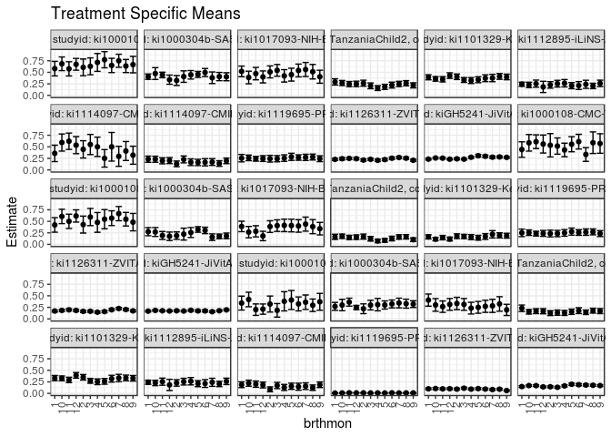

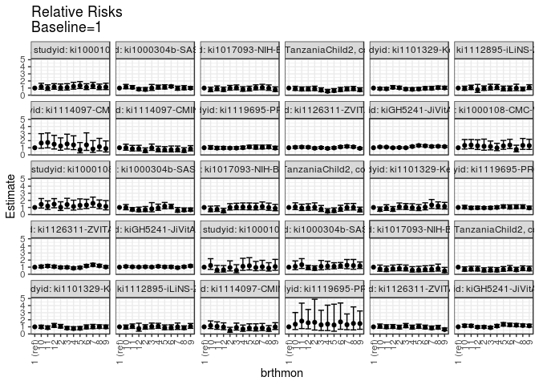

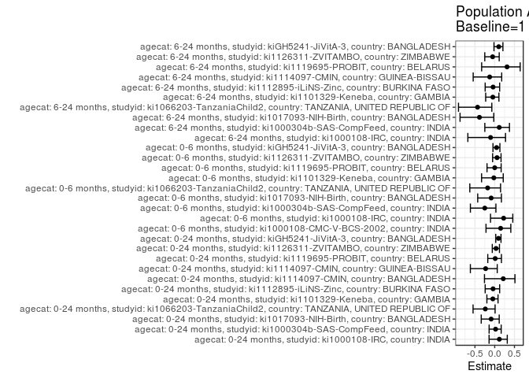

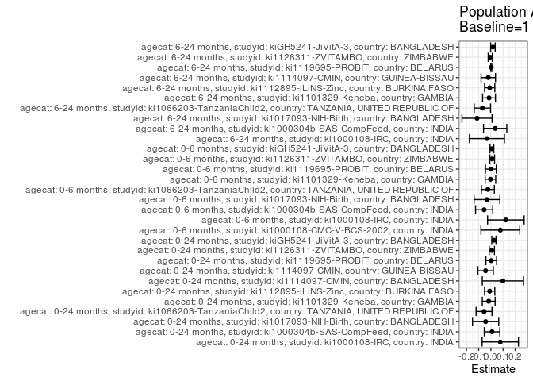

## Results Table

### Parameter: TSM

| agecat | studyid | country | intervention_level | baseline_level | estimate | ci_lower | ci_upper |
| --- | --- | --- | --- | --- | --- | --- | --- |
| 0-24 months | ki1000108-IRC | INDIA | 1 | NA | 0.5789474 | 0.4217757 | 0.7361191 |
| 0-24 months | ki1000108-IRC | INDIA | 2 | NA | 0.6071429 | 0.4260246 | 0.7882611 |
| 0-24 months | ki1000108-IRC | INDIA | 3 | NA | 0.6296296 | 0.4472580 | 0.8120012 |
| 0-24 months | ki1000108-IRC | INDIA | 4 | NA | 0.7142857 | 0.5208348 | 0.9077366 |
| 0-24 months | ki1000108-IRC | INDIA | 5 | NA | 0.7727273 | 0.5973983 | 0.9480563 |
| 0-24 months | ki1000108-IRC | INDIA | 6 | NA | 0.6486486 | 0.4946372 | 0.8026601 |
| 0-24 months | ki1000108-IRC | INDIA | 7 | NA | 0.7500000 | 0.6083790 | 0.8916210 |
| 0-24 months | ki1000108-IRC | INDIA | 8 | NA | 0.6363636 | 0.4940527 | 0.7786746 |
| 0-24 months | ki1000108-IRC | INDIA | 9 | NA | 0.6666667 | 0.4886379 | 0.8446955 |
| 0-24 months | ki1000108-IRC | INDIA | 10 | NA | 0.6842105 | 0.5362383 | 0.8321828 |
| 0-24 months | ki1000108-IRC | INDIA | 11 | NA | 0.5750000 | 0.4216172 | 0.7283828 |
| 0-24 months | ki1000108-IRC | INDIA | 12 | NA | 0.6730769 | 0.5454237 | 0.8007302 |
| 0-24 months | ki1000304b-SAS-CompFeed | INDIA | 1 | NA | 0.4054054 | 0.3471898 | 0.4636211 |
| 0-24 months | ki1000304b-SAS-CompFeed | INDIA | 2 | NA | 0.3222222 | 0.2151731 | 0.4292713 |
| 0-24 months | ki1000304b-SAS-CompFeed | INDIA | 3 | NA | 0.4074074 | 0.2830856 | 0.5317292 |
| 0-24 months | ki1000304b-SAS-CompFeed | INDIA | 4 | NA | 0.4459459 | 0.3540735 | 0.5378184 |
| 0-24 months | ki1000304b-SAS-CompFeed | INDIA | 5 | NA | 0.4545455 | 0.3896936 | 0.5193973 |
| 0-24 months | ki1000304b-SAS-CompFeed | INDIA | 6 | NA | 0.4954128 | 0.4080359 | 0.5827898 |
| 0-24 months | ki1000304b-SAS-CompFeed | INDIA | 7 | NA | 0.3823529 | 0.2568594 | 0.5078465 |
| 0-24 months | ki1000304b-SAS-CompFeed | INDIA | 8 | NA | 0.4078212 | 0.3185845 | 0.4970580 |
| 0-24 months | ki1000304b-SAS-CompFeed | INDIA | 9 | NA | 0.4031414 | 0.3162761 | 0.4900066 |
| 0-24 months | ki1000304b-SAS-CompFeed | INDIA | 10 | NA | 0.4727273 | 0.3441071 | 0.6013474 |
| 0-24 months | ki1000304b-SAS-CompFeed | INDIA | 11 | NA | 0.4428571 | 0.3830563 | 0.5026580 |
| 0-24 months | ki1000304b-SAS-CompFeed | INDIA | 12 | NA | 0.3405797 | 0.2402558 | 0.4409037 |
| 0-24 months | ki1017093-NIH-Birth | BANGLADESH | 1 | NA | 0.5205479 | 0.4058547 | 0.6352412 |
| 0-24 months | ki1017093-NIH-Birth | BANGLADESH | 2 | NA | 0.5087719 | 0.3788860 | 0.6386579 |
| 0-24 months | ki1017093-NIH-Birth | BANGLADESH | 3 | NA | 0.5423729 | 0.4151471 | 0.6695987 |
| 0-24 months | ki1017093-NIH-Birth | BANGLADESH | 4 | NA | 0.4230769 | 0.2886880 | 0.5574658 |
| 0-24 months | ki1017093-NIH-Birth | BANGLADESH | 5 | NA | 0.4489796 | 0.3096012 | 0.5883580 |
| 0-24 months | ki1017093-NIH-Birth | BANGLADESH | 6 | NA | 0.5400000 | 0.4017430 | 0.6782570 |

[output cut: 330 more lines]

### Parameter: E(Y)

| agecat | studyid | country | intervention_level | baseline_level | estimate | ci_lower | ci_upper |
| --- | --- | --- | --- | --- | --- | --- | --- |
| 0-24 months | ki1000108-IRC | INDIA | NA | NA | 0.6560976 | 0.6100625 | 0.7021326 |
| 0-24 months | ki1000304b-SAS-CompFeed | INDIA | NA | NA | 0.4150694 | 0.3581204 | 0.4720184 |
| 0-24 months | ki1017093-NIH-Birth | BANGLADESH | NA | NA | 0.4775641 | 0.4383415 | 0.5167867 |
| 0-24 months | ki1066203-TanzaniaChild2 | TANZANIA, UNITED REPUBLIC OF | NA | NA | 0.2362270 | 0.2192156 | 0.2532385 |
| 0-24 months | ki1101329-Keneba | GAMBIA | NA | NA | 0.3741007 | 0.3565437 | 0.3916578 |
| 0-24 months | ki1112895-iLiNS-Zinc | BURKINA FASO | NA | NA | 0.2317820 | 0.2038933 | 0.2596707 |
| 0-24 months | ki1114097-CMIN | BANGLADESH | NA | NA | 0.4558824 | 0.3965849 | 0.5151798 |
| 0-24 months | ki1114097-CMIN | GUINEA-BISSAU | NA | NA | 0.1884539 | 0.1687026 | 0.2082051 |
| 0-24 months | ki1119695-PROBIT | BELARUS | NA | NA | 0.2565984 | 0.1993515 | 0.3138454 |
| 0-24 months | ki1126311-ZVITAMBO | ZIMBABWE | NA | NA | 0.2347371 | 0.2277008 | 0.2417734 |
| 0-24 months | kiGH5241-JiVitA-3 | BANGLADESH | NA | NA | 0.2580861 | 0.2516266 | 0.2645455 |
| 0-6 months | ki1000108-CMC-V-BCS-2002 | INDIA | NA | NA | 0.5190217 | 0.4679041 | 0.5701394 |
| 0-6 months | ki1000108-IRC | INDIA | NA | NA | 0.5439024 | 0.4956326 | 0.5921723 |
| 0-6 months | ki1000304b-SAS-CompFeed | INDIA | NA | NA | 0.2199336 | 0.1753445 | 0.2645227 |
| 0-6 months | ki1017093-NIH-Birth | BANGLADESH | NA | NA | 0.3569132 | 0.3192325 | 0.3945938 |
| 0-6 months | ki1066203-TanzaniaChild2 | TANZANIA, UNITED REPUBLIC OF | NA | NA | 0.1389816 | 0.1251275 | 0.1528358 |
| 0-6 months | ki1101329-Keneba | GAMBIA | NA | NA | 0.1592121 | 0.1446830 | 0.1737413 |
| 0-6 months | ki1119695-PROBIT | BELARUS | NA | NA | 0.2497780 | 0.1917926 | 0.3077635 |
| 0-6 months | ki1126311-ZVITAMBO | ZIMBABWE | NA | NA | 0.1810500 | 0.1746363 | 0.1874638 |
| 0-6 months | kiGH5241-JiVitA-3 | BANGLADESH | NA | NA | 0.1763020 | 0.1706791 | 0.1819248 |
| 6-24 months | ki1000108-IRC | INDIA | NA | NA | 0.3097561 | 0.2649438 | 0.3545684 |
| 6-24 months | ki1000304b-SAS-CompFeed | INDIA | NA | NA | 0.3059755 | 0.2638053 | 0.3481458 |
| 6-24 months | ki1017093-NIH-Birth | BANGLADESH | NA | NA | 0.2939002 | 0.2554778 | 0.3323226 |
| 6-24 months | ki1066203-TanzaniaChild2 | TANZANIA, UNITED REPUBLIC OF | NA | NA | 0.1605550 | 0.1445335 | 0.1765765 |
| 6-24 months | ki1101329-Keneba | GAMBIA | NA | NA | 0.3170197 | 0.2995873 | 0.3344522 |
| 6-24 months | ki1112895-iLiNS-Zinc | BURKINA FASO | NA | NA | 0.2317820 | 0.2038933 | 0.2596707 |
| 6-24 months | ki1114097-CMIN | GUINEA-BISSAU | NA | NA | 0.1666667 | 0.1476863 | 0.1856470 |
| 6-24 months | ki1119695-PROBIT | BELARUS | NA | NA | 0.0100615 | 0.0072668 | 0.0128561 |
| 6-24 months | ki1126311-ZVITAMBO | ZIMBABWE | NA | NA | 0.0939779 | 0.0884472 | 0.0995086 |
| 6-24 months | kiGH5241-JiVitA-3 | BANGLADESH | NA | NA | 0.1640074 | 0.1578946 | 0.1701202 |

### Parameter: RR

| agecat | studyid | country | intervention_level | baseline_level | estimate | ci_lower | ci_upper |
| --- | --- | --- | --- | --- | --- | --- | --- |
| 0-24 months | ki1000108-IRC | INDIA | 1 | 1 | 1.0000000 | 1.0000000 | 1.0000000 |
| 0-24 months | ki1000108-IRC | INDIA | 2 | 1 | 1.0487013 | 0.7006149 | 1.5697274 |
| 0-24 months | ki1000108-IRC | INDIA | 3 | 1 | 1.0875421 | 0.7312026 | 1.6175378 |
| 0-24 months | ki1000108-IRC | INDIA | 4 | 1 | 1.2337662 | 0.8408016 | 1.8103904 |
| 0-24 months | ki1000108-IRC | INDIA | 5 | 1 | 1.3347107 | 0.9369768 | 1.9012773 |
| 0-24 months | ki1000108-IRC | INDIA | 6 | 1 | 1.1203931 | 0.7811561 | 1.6069525 |
| 0-24 months | ki1000108-IRC | INDIA | 7 | 1 | 1.2954545 | 0.9306897 | 1.8031815 |
| 0-24 months | ki1000108-IRC | INDIA | 8 | 1 | 1.0991736 | 0.7732383 | 1.5624969 |
| 0-24 months | ki1000108-IRC | INDIA | 9 | 1 | 1.1515152 | 0.7868430 | 1.6851991 |
| 0-24 months | ki1000108-IRC | INDIA | 10 | 1 | 1.1818182 | 0.8352396 | 1.6722078 |
| 0-24 months | ki1000108-IRC | INDIA | 11 | 1 | 0.9931818 | 0.6787903 | 1.4531884 |
| 0-24 months | ki1000108-IRC | INDIA | 12 | 1 | 1.1625874 | 0.8348389 | 1.6190064 |
| 0-24 months | ki1000304b-SAS-CompFeed | INDIA | 1 | 1 | 1.0000000 | 1.0000000 | 1.0000000 |
| 0-24 months | ki1000304b-SAS-CompFeed | INDIA | 2 | 1 | 0.7948148 | 0.5858925 | 1.0782363 |
| 0-24 months | ki1000304b-SAS-CompFeed | INDIA | 3 | 1 | 1.0049383 | 0.6719218 | 1.5030036 |
| 0-24 months | ki1000304b-SAS-CompFeed | INDIA | 4 | 1 | 1.1000000 | 0.8568562 | 1.4121389 |
| 0-24 months | ki1000304b-SAS-CompFeed | INDIA | 5 | 1 | 1.1212121 | 0.8626481 | 1.4572762 |
| 0-24 months | ki1000304b-SAS-CompFeed | INDIA | 6 | 1 | 1.2220183 | 1.0612369 | 1.4071589 |
| 0-24 months | ki1000304b-SAS-CompFeed | INDIA | 7 | 1 | 0.9431373 | 0.7016928 | 1.2676601 |
| 0-24 months | ki1000304b-SAS-CompFeed | INDIA | 8 | 1 | 1.0059590 | 0.7564215 | 1.3378170 |
| 0-24 months | ki1000304b-SAS-CompFeed | INDIA | 9 | 1 | 0.9944154 | 0.8187732 | 1.2077360 |
| 0-24 months | ki1000304b-SAS-CompFeed | INDIA | 10 | 1 | 1.1660606 | 0.8988349 | 1.5127332 |
| 0-24 months | ki1000304b-SAS-CompFeed | INDIA | 11 | 1 | 1.0923810 | 0.8868584 | 1.3455317 |
| 0-24 months | ki1000304b-SAS-CompFeed | INDIA | 12 | 1 | 0.8400966 | 0.6689409 | 1.0550444 |
| 0-24 months | ki1017093-NIH-Birth | BANGLADESH | 1 | 1 | 1.0000000 | 1.0000000 | 1.0000000 |
| 0-24 months | ki1017093-NIH-Birth | BANGLADESH | 2 | 1 | 0.9773777 | 0.6976016 | 1.3693590 |
| 0-24 months | ki1017093-NIH-Birth | BANGLADESH | 3 | 1 | 1.0419269 | 0.7552158 | 1.4374853 |
| 0-24 months | ki1017093-NIH-Birth | BANGLADESH | 4 | 1 | 0.8127530 | 0.5521643 | 1.1963241 |
| 0-24 months | ki1017093-NIH-Birth | BANGLADESH | 5 | 1 | 0.8625134 | 0.5894403 | 1.2620946 |
| 0-24 months | ki1017093-NIH-Birth | BANGLADESH | 6 | 1 | 1.0373684 | 0.7400059 | 1.4542226 |

[output cut: 330 more lines]

### Parameter: PAR

| agecat | studyid | country | intervention_level | baseline_level | estimate | ci_lower | ci_upper |
| --- | --- | --- | --- | --- | --- | --- | --- |
| 0-24 months | ki1000108-IRC | INDIA | 1 | NA | 0.0771502 | -0.0719909 | 0.2262913 |
| 0-24 months | ki1000304b-SAS-CompFeed | INDIA | 1 | NA | 0.0096640 | -0.0541265 | 0.0734545 |
| 0-24 months | ki1017093-NIH-Birth | BANGLADESH | 1 | NA | -0.0429838 | -0.1507574 | 0.0647897 |
| 0-24 months | ki1066203-TanzaniaChild2 | TANZANIA, UNITED REPUBLIC OF | 1 | NA | -0.0561706 | -0.1215586 | 0.0092173 |
| 0-24 months | ki1101329-Keneba | GAMBIA | 1 | NA | -0.0177912 | -0.0704661 | 0.0348837 |
| 0-24 months | ki1112895-iLiNS-Zinc | BURKINA FASO | 1 | NA | -0.0097041 | -0.0516561 | 0.0322479 |
| 0-24 months | ki1114097-CMIN | BANGLADESH | 1 | NA | 0.0987395 | -0.0704417 | 0.2679207 |
| 0-24 months | ki1114097-CMIN | GUINEA-BISSAU | 1 | NA | -0.0433342 | -0.1066955 | 0.0200271 |
| 0-24 months | ki1119695-PROBIT | BELARUS | 1 | NA | 0.0031871 | -0.0407264 | 0.0471006 |
| 0-24 months | ki1126311-ZVITAMBO | ZIMBABWE | 1 | NA | 0.0079713 | -0.0133287 | 0.0292713 |
| 0-24 months | kiGH5241-JiVitA-3 | BANGLADESH | 1 | NA | 0.0246993 | 0.0075936 | 0.0418051 |
| 0-6 months | ki1000108-CMC-V-BCS-2002 | INDIA | 1 | NA | 0.0778453 | -0.0814746 | 0.2371651 |
| 0-6 months | ki1000108-IRC | INDIA | 1 | NA | 0.1228498 | -0.0269962 | 0.2726958 |
| 0-6 months | ki1000304b-SAS-CompFeed | INDIA | 1 | NA | -0.0552958 | -0.1258548 | 0.0152632 |
| 0-6 months | ki1017093-NIH-Birth | BANGLADESH | 1 | NA | -0.0319757 | -0.1377100 | 0.0737586 |
| 0-6 months | ki1066203-TanzaniaChild2 | TANZANIA, UNITED REPUBLIC OF | 1 | NA | -0.0247611 | -0.0779595 | 0.0284374 |
| 0-6 months | ki1101329-Keneba | GAMBIA | 1 | NA | -0.0034863 | -0.0466017 | 0.0396291 |
| 0-6 months | ki1119695-PROBIT | BELARUS | 1 | NA | 0.0000219 | -0.0444072 | 0.0444510 |
| 0-6 months | ki1126311-ZVITAMBO | ZIMBABWE | 1 | NA | 0.0108693 | -0.0084000 | 0.0301386 |
| 0-6 months | kiGH5241-JiVitA-3 | BANGLADESH | 1 | NA | 0.0084305 | -0.0070203 | 0.0238813 |
| 6-24 months | ki1000108-IRC | INDIA | 1 | NA | -0.0323492 | -0.1758358 | 0.1111375 |
| 6-24 months | ki1000304b-SAS-CompFeed | INDIA | 1 | NA | 0.0351422 | -0.0603771 | 0.1306614 |
| 6-24 months | ki1017093-NIH-Birth | BANGLADESH | 1 | NA | -0.1135072 | -0.2369892 | 0.0099747 |
| 6-24 months | ki1066203-TanzaniaChild2 | TANZANIA, UNITED REPUBLIC OF | 1 | NA | -0.0696608 | -0.1366064 | -0.0027153 |
| 6-24 months | ki1101329-Keneba | GAMBIA | 1 | NA | -0.0150971 | -0.0679384 | 0.0377443 |
| 6-24 months | ki1112895-iLiNS-Zinc | BURKINA FASO | 1 | NA | -0.0097041 | -0.0516561 | 0.0322479 |
| 6-24 months | ki1114097-CMIN | GUINEA-BISSAU | 1 | NA | -0.0212528 | -0.0804615 | 0.0379559 |
| 6-24 months | ki1119695-PROBIT | BELARUS | 1 | NA | 0.0031445 | -0.0012828 | 0.0075717 |
| 6-24 months | ki1126311-ZVITAMBO | ZIMBABWE | 1 | NA | -0.0049754 | -0.0220765 | 0.0121256 |
| 6-24 months | kiGH5241-JiVitA-3 | BANGLADESH | 1 | NA | 0.0166925 | -0.0018219 | 0.0352068 |

### Parameter: PAF

| agecat | studyid | country | intervention_level | baseline_level | estimate | ci_lower | ci_upper |
| --- | --- | --- | --- | --- | --- | --- | --- |
| 0-24 months | ki1000108-IRC | INDIA | 1 | NA | 0.1175895 | -0.1421481 | 0.3182598 |
| 0-24 months | ki1000304b-SAS-CompFeed | INDIA | 1 | NA | 0.0232828 | -0.1411654 | 0.1640332 |
| 0-24 months | ki1017093-NIH-Birth | BANGLADESH | 1 | NA | -0.0900064 | -0.3408885 | 0.1139352 |
| 0-24 months | ki1066203-TanzaniaChild2 | TANZANIA, UNITED REPUBLIC OF | 1 | NA | -0.2377823 | -0.5478204 | 0.0101532 |
| 0-24 months | ki1101329-Keneba | GAMBIA | 1 | NA | -0.0475572 | -0.1982678 | 0.0841980 |
| 0-24 months | ki1112895-iLiNS-Zinc | BURKINA FASO | 1 | NA | -0.0418672 | -0.2409749 | 0.1252947 |
| 0-24 months | ki1114097-CMIN | BANGLADESH | 1 | NA | 0.2165899 | -0.2586442 | 0.5123869 |
| 0-24 months | ki1114097-CMIN | GUINEA-BISSAU | 1 | NA | -0.2299459 | -0.6161192 | 0.0639509 |
| 0-24 months | ki1119695-PROBIT | BELARUS | 1 | NA | 0.0124206 | -0.1753247 | 0.1701756 |
| 0-24 months | ki1126311-ZVITAMBO | ZIMBABWE | 1 | NA | 0.0339583 | -0.0611772 | 0.1205648 |
| 0-24 months | kiGH5241-JiVitA-3 | BANGLADESH | 1 | NA | 0.0957020 | 0.0268564 | 0.1596770 |
| 0-6 months | ki1000108-CMC-V-BCS-2002 | INDIA | 1 | NA | 0.1499846 | -0.2201490 | 0.4078378 |
| 0-6 months | ki1000108-IRC | INDIA | 1 | NA | 0.2258674 | -0.1059101 | 0.4581103 |
| 0-6 months | ki1000304b-SAS-CompFeed | INDIA | 1 | NA | -0.2514205 | -0.6153667 | 0.0305277 |
| 0-6 months | ki1017093-NIH-Birth | BANGLADESH | 1 | NA | -0.0895896 | -0.4300627 | 0.1698228 |
| 0-6 months | ki1066203-TanzaniaChild2 | TANZANIA, UNITED REPUBLIC OF | 1 | NA | -0.1781606 | -0.6300782 | 0.1484688 |
| 0-6 months | ki1101329-Keneba | GAMBIA | 1 | NA | -0.0218970 | -0.3319690 | 0.2159927 |
| 0-6 months | ki1119695-PROBIT | BELARUS | 1 | NA | 0.0000879 | -0.1945952 | 0.1630434 |
| 0-6 months | ki1126311-ZVITAMBO | ZIMBABWE | 1 | NA | 0.0600349 | -0.0526414 | 0.1606502 |
| 0-6 months | kiGH5241-JiVitA-3 | BANGLADESH | 1 | NA | 0.0478185 | -0.0438879 | 0.1314684 |
| 6-24 months | ki1000108-IRC | INDIA | 1 | NA | -0.1044343 | -0.6799327 | 0.2739143 |
| 6-24 months | ki1000304b-SAS-CompFeed | INDIA | 1 | NA | 0.1148529 | -0.2501475 | 0.3732857 |
| 6-24 months | ki1017093-NIH-Birth | BANGLADESH | 1 | NA | -0.3862101 | -0.8776149 | -0.0234146 |
| 6-24 months | ki1066203-TanzaniaChild2 | TANZANIA, UNITED REPUBLIC OF | 1 | NA | -0.4338751 | -0.9164352 | -0.0728241 |
| 6-24 months | ki1101329-Keneba | GAMBIA | 1 | NA | -0.0476219 | -0.2282949 | 0.1064755 |
| 6-24 months | ki1112895-iLiNS-Zinc | BURKINA FASO | 1 | NA | -0.0418672 | -0.2409749 | 0.1252947 |
| 6-24 months | ki1114097-CMIN | GUINEA-BISSAU | 1 | NA | -0.1275168 | -0.5448823 | 0.1770933 |
| 6-24 months | ki1119695-PROBIT | BELARUS | 1 | NA | 0.3125251 | -0.3302751 | 0.6447188 |
| 6-24 months | ki1126311-ZVITAMBO | ZIMBABWE | 1 | NA | -0.0529427 | -0.2515572 | 0.1141529 |
| 6-24 months | kiGH5241-JiVitA-3 | BANGLADESH | 1 | NA | 0.1017786 | -0.0185809 | 0.2079160 |